# University students Study Habits and Screen Time

## Exploration of university students and balance between study and phone use

TThis visual data story explores how university students balance study time and phone use. The data was collected through a self reported survey completed by university students across two periods to capture observational behaviours related to study habits, screen time, and phone usage. Some variables, such as personal study hours, were added in the updated survey form, so some visualisations only use the most recent complete responses.

The visualisations investigate relationships between university study habits, phone behaviour, and screen time patterns across the week, using different variables compared to Project 2. As the data was self reported and observational, the visualisations are intended to explore patterns and relationships rather than prove causation.

## University time and personal study

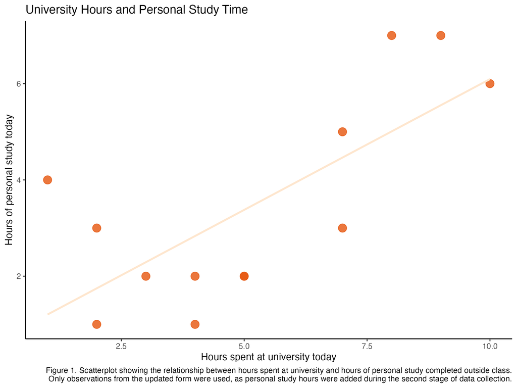

Scatterplot comparing hours spent at university and hours of personal study completed outside class, to investigate whether students who spend longer at university also tend to complete more independent study. Hours spent at university on the x-axis and hours of personal study on the y-axis, with an slight positive linear trend line across the data points but with high variaiton

This visualisation explores the relationship between time spent at university and personal study completed outside class. The scatterplot suggests a slight positive relationship, where students who spent longer at university often also tended to complete more personal study.

However, there is high variation between responses, indicating that university attendance alone does not fully explain differences in personal study time.

Only observations from the updated survey form were used because personal study hours were added during the second stage of data collection.

## Phone usage and screen time

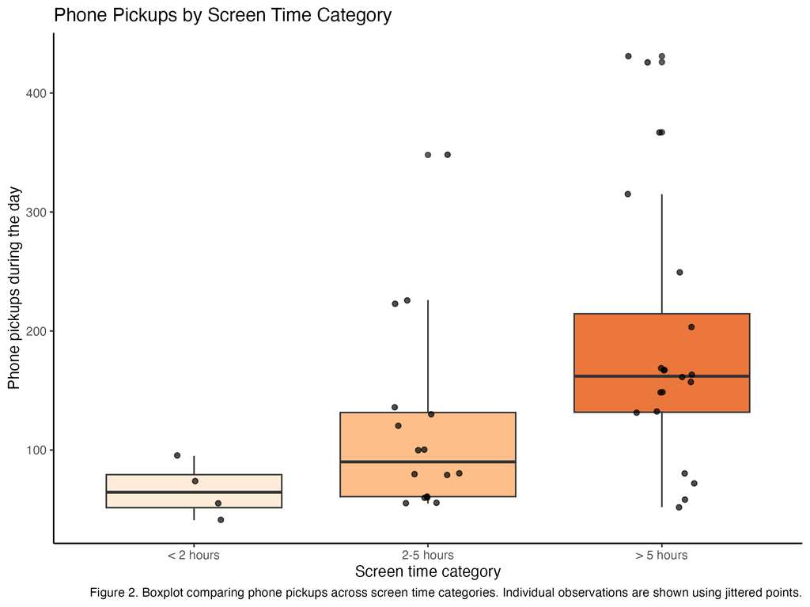

Boxplot comparing phone pickups across low, medium, and high screen time categories, to examine whether higher screen time is associated with more frequent phone checking behaviour.Higher screen time groups generally had more phone pickups and greater variation in phone use

This visualisation compares phone pickups across different screen time categories to investigate whether students with higher reported screen time also tended to check their phones more frequently during the day.

Students in the higher screen time category generally recorded substantially more phone pickups than students in the lower screen time groups. The distribution also became more variable as screen time increased, with several students in the high screen time category recording very large numbers of phone pickups.

The jittered points help display the individual observations within each category, while the boxplots summarise the median and spread of the data.

## Screen time across the week

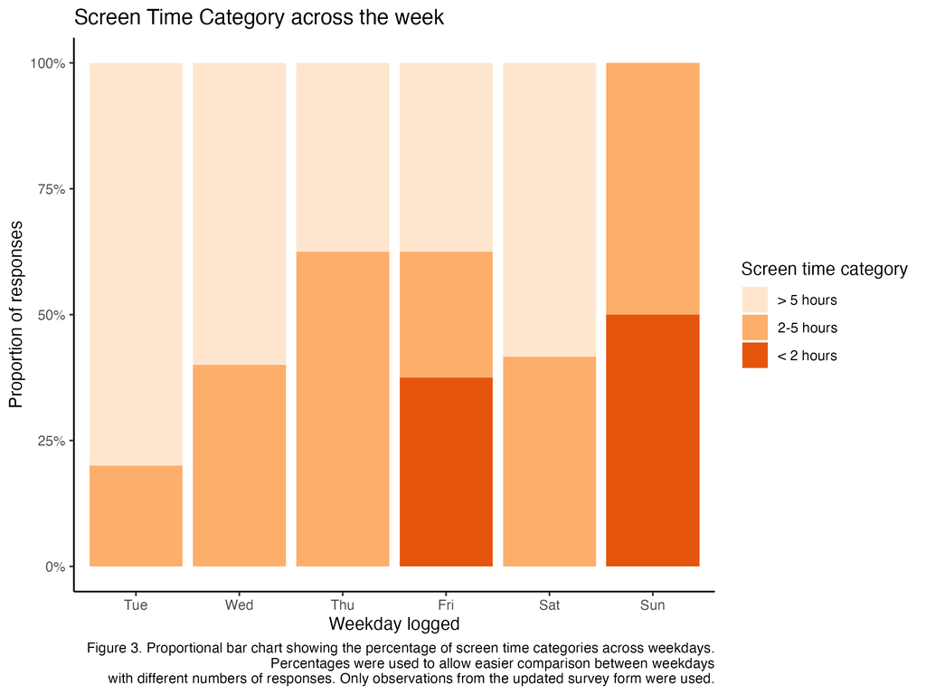

Proportional bar chart showing the percentage of low, medium, and high screen time categories across weekdays, to compare how screen time patterns vary throughout the week. Higher screen time responses were more common earlier in the week

This visualisation compares screen time categories across weekdays using proportional bar charts. We used timestamps converted into weekdays and percentages were used instead of raw counts because the number of responses differed between weekdays, making proportional comparisons more appropriate.

Higher screen time responses appeared more common earlier in the week, particularly on Tuesday and Wednesday, while lower screen time responses became more common by Sunday. Medium screen time (2-5 hours) responses were present across all weekdays.